# Trabajo Práctico II

Constanza Guerrini

# <sup>Introducción</sup>

Los datos que se utilizarán en el presente trabajo son datos sobre las tasas de actividad por sexo desde el año 2003 al 2019 en la Ciudad Autónoma de Buenos Aires.

Fueron tomados por la Dirección General de Estadística y Censos del Ministerio de Economía y Finanzas de la Ciudad Autónoma de Buenos Aires entre los años 2003 y 2019.

## Exploración de los datos

```r
datos_tp <- read.csv("datos/tas_act_sexo__annio_limpio.csv")
```

### *Nombre de las variables y Resumen estadístico de los datos:*

```r
names(datos_tp)
```

```
## [1] "anio"           "sexo"           "tasa_actividad"
```

```r
summary(datos_tp)
```

```
##       anio          sexo           tasa_actividad
##  Min.   :2003   Length:51          Min.   :52.30
##  1st Qu.:2007   Class :character   1st Qu.:57.15
##  Median :2011   Mode  :character   Median :62.40
##  Mean   :2011                      Mean   :62.92
##  3rd Qu.:2015                      3rd Qu.:70.40
##  Max.   :2019                      Max.   :72.60
```

### *Valores Medios y Desvío Estándar*

```r
media <- datos_tp |>
  group_by(sexo) |>
  summarise(tasa_actividad = mean(tasa_actividad))
```

```r
sd <- datos_tp |>
  group_by(sexo) |>
  summarise(tasa_actividad = sd(tasa_actividad))
```

La media de la tasa de actividad masculina supera por 15.96632 a la media de la tasa de actividad femenina.

### *Rango de los datos*

**General**

```r
max(filter(datos_tp, sexo=="TOTAL")$tasa_actividad) - min(filter(datos_tp, sexo=="TOTAL")$tasa_actividad)
```

```
## [1] 4.3
```

**Varones**

```r
max(filter(datos_tp, sexo=="v")$tasa_actividad) - min(filter(datos_tp, sexo=="v")$tasa_actividad)
```

```
## [1] 3.3
```

**Mujeres**

```r
max(filter(datos_tp, sexo=="m")$tasa_actividad) - min(filter(datos_tp, sexo=="m")$tasa_actividad)
```

```
## [1] 6.6
```

La tasa de actividad sin distinción por sexo muestra un rango de 4.3. Mientras que el rango de la tasa de actividad masculina es de 3.3 y el de la femenina de 6.6.

No se observan anomalías que sugieran datos incorrectos.

### *Observaciones por cada grupo*

```r
str(datos_tp)
```

```
## 'data.frame':    51 obs. of  3 variables:
##  $ anio          : int  2003 2003 2003 2004 2004 2004 2005 2005 2005 2006 ...
##  $ sexo          : chr  "TOTAL" "m" "v" "TOTAL" ...
##  $ tasa_actividad: num  60.7 52.3 70.9 61.7 53.9 71.3 62.5 55 71.4 62 ...
```

El data frame “datos_tp” tiene 51 observaciones y 3 variables.

```r
anyNA(datos_tp)
```

```
## [1] FALSE
```

No se observan valores faltantes.

# Hipótesis

1. **Durante el período 2015-2019 hubo una reducción de la tasa de actividad masculiuna.**

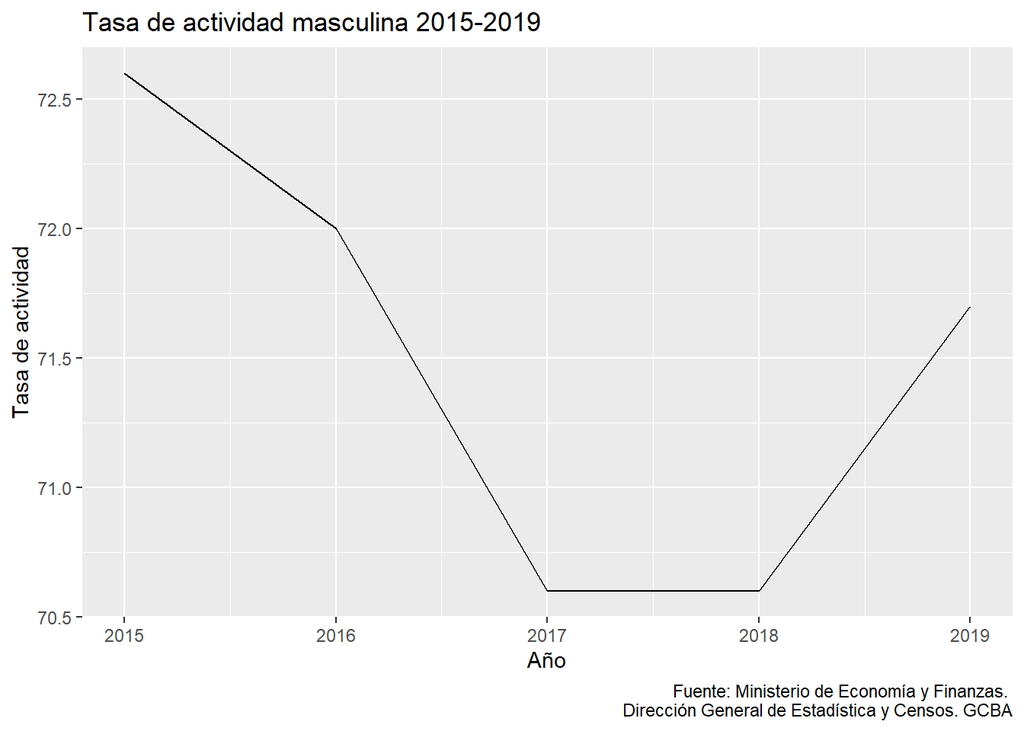

   ```r
    periodo <- filter(datos_tp, anio>=2015 & sexo=='v')

      ggplot(data = periodo, aes(x = anio , y = tasa_actividad)) +
     geom_line() +
     labs(x= "Año",
          y= "Tasa de actividad",
          title= "Tasa de actividad masculina 2015-2019",
          caption = "Fuente: Ministerio de Economía y Finanzas.
          Dirección General de Estadística y Censos. GCBA")
   ```

   Como se puede observar en el gráfico, durante el período 2015-2019 se produce una baja de la tasa de actividad masculina.
2. **Existe una brecha de género en la tasa de actividad. La tasa de actividad promedio de las mujeres es menor que la tasa de actividad promedio de los varones.**

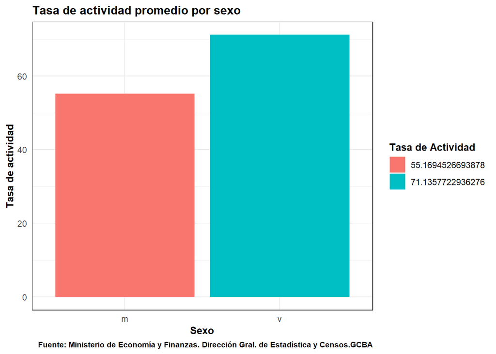

```r
tasa_filtrada <- filter(media, sexo  != "TOTAL")

ggplot(tasa_filtrada)+
  geom_col(aes(x=sexo,
                y= tasa_actividad, fill=factor(tasa_actividad)))+

labs(x= "Sexo",
       y= "Tasa de actividad",
       title= "Tasa de actividad promedio por sexo",
       caption = "Fuente: Ministerio de Economía y Finanzas. Dirección Gral. de Estadística y Censos.GCBA") +
  guides(fill = guide_legend(title="Tasa de Actividad")) +
  theme_minimal() +
  theme(panel.border = element_rect(color = "black", fill = NA))+
  theme(title = element_text(size = 10, face = "bold"))
```

**Brecha de género: Serie temporal de la tasa de actividad masculina y femenina 2015-2019**

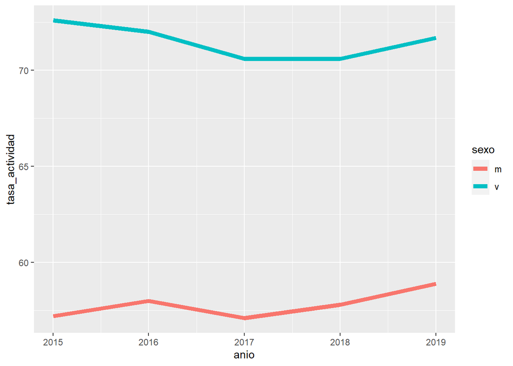

```r
brecha <- datos_tp %>%
  filter(anio >=2015 & sexo != "TOTAL")

ggplot(data = brecha, aes(x = anio, y = tasa_actividad))+
     geom_line(aes(group = sexo, color=sexo), size=2)
```

Finalmente se puede apreciar que existe una gran brecha de género entre la tasa de actividad femenina y la tasa de actividad masculina. Esta brecha es de entre 15 y 13 puntos y fue disminuyendo con el correr de los años dentro del período analizado.